# Logistic Regression

2018204094 박형빈

# 1 Import Data

**인구 데이터 기반 소득 예측 경진대회 데이터**인 데이터셋(income.csv)을 활용, Logistic Regression model을 구축하여 인구 데이터를 바탕으로 **소득이 5만달러 초과(1)인지 이하(0)인지 분류**하였다.

```r
# 현재 경로를 받아서 dataset을 불러옵니다
wd <- getwd()
setwd(wd)
rm(wd)

income <- read.csv('income.csv', header= T, na.strings = c("", " ", NA)) # 결측치를 받아옵니다
head(income)
```

```
##   id age workclass fnlwgt    education education.num     marital.status
## 1  0  32   Private 309513   Assoc-acdm            12 Married-civ-spouse
## 2  1  33   Private 205469 Some-college            10 Married-civ-spouse
## 3  2  46   Private 149949 Some-college            10 Married-civ-spouse
## 4  3  23   Private 193090    Bachelors            13      Never-married
## 5  4  55   Private  60193      HS-grad             9           Divorced
## 6  5  33   Private  41610    Bachelors            13 Married-civ-spouse
##        occupation  relationship  race    sex capital.gain capital.loss
## 1    Craft-repair       Husband White   Male            0            0
## 2 Exec-managerial       Husband White   Male            0            0
## 3    Craft-repair       Husband White   Male            0            0
## 4    Adm-clerical     Own-child White Female            0            0
## 5    Adm-clerical Not-in-family White Female            0            0
## 6  Prof-specialty       Husband White   Male            0            0
##   hours.per.week native.country target
## 1             40  United-States      0
## 2             40  United-States      1
## 3             40  United-States      0
## 4             30  United-States      0
## 5             40  United-States      0
## 6             40  United-States      0
```

# 2 EDA

인구 데이터(income)의 전체적인 EDA 결과 요약은 다음과 같이 정리할 수 있다.  
구체적인 EDA 과정은 코드와 주석을 통해 확인할 수 있다.

**17,480 rows X 16 cols**

**X variables**

- feature column
  - id
    - 식별자 정보는 학습에 유의하지 않으므로 제거할 예정
- Categorical 범주형 (실수형이 아닌)
  - workclass : 일 유형 (9)
  - education : 교육수준 (16)
  - education : 교육수준 번호
    - EDA 결과 교육수준 변수를 숫자값으로 mapping 한 것이 교육수준 번호 변수임을 확인, 해당 변수를 대신 제거할 예정
  - marital.status : 결혼 상태 (7)
  - occupation : 직업 (15)
  - relationship : 가족관계 (6)
  - race : 인종 (5)
  - sex : 성별 (2)
  - native.country : 본 국적 (42)
- Numerical 연속형 (실수형인)
  - age : 나이
  - fnlwgt : CPS(Current Population Survey)가중치
  - capital.gain : 자본 이익
  - capital.loss : 자본 손실
  - hours.per.week : 주당 근무시간

**y variable**

- target : 소득
  - 0 : 5만 달러 이하 (50k<=)
  - 1 : 5만 달러 초과 (>50k)
  - label이 [0,1]로 되어 있는 Binary Classification 문제로 생각할 수 있다

```r
# 데이터의 기본 구조를 확인합니다
str(income)
```

```
## 'data.frame':    17480 obs. of  16 variables:
##  $ id            : int  0 1 2 3 4 5 6 7 8 9 ...
##  $ age           : int  32 33 46 23 55 33 40 45 17 35 ...
##  $ workclass     : chr  "Private" "Private" "Private" "Private" ...
##  $ fnlwgt        : int  309513 205469 149949 193090 60193 41610 40024 114797 39815 107991 ...
##  $ education     : chr  "Assoc-acdm" "Some-college" "Some-college" "Bachelors" ...
##  $ education.num : int  12 10 10 13 9 13 15 9 6 7 ...
##  $ marital.status: chr  "Married-civ-spouse" "Married-civ-spouse" "Married-civ-spouse" "Never-married" ...
##  $ occupation    : chr  "Craft-repair" "Exec-managerial" "Craft-repair" "Adm-clerical" ...
##  $ relationship  : chr  "Husband" "Husband" "Husband" "Own-child" ...
##  $ race          : chr  "White" "White" "White" "White" ...
##  $ sex           : chr  "Male" "Male" "Male" "Female" ...
##  $ capital.gain  : int  0 0 0 0 0 0 0 0 0 0 ...
##  $ capital.loss  : int  0 0 0 0 0 0 0 0 0 0 ...
##  $ hours.per.week: int  40 40 40 30 40 40 38 40 25 45 ...
##  $ native.country: chr  "United-States" "United-States" "United-States" "United-States" ...
##  $ target        : int  0 1 0 0 0 0 1 0 0 0 ...
```

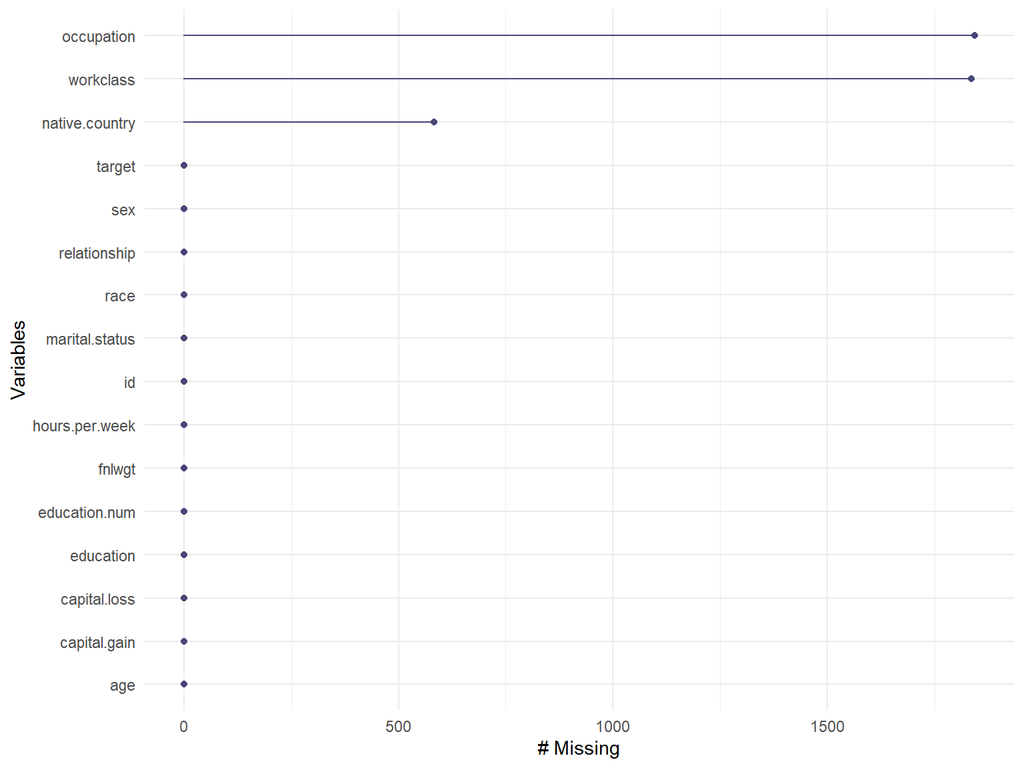

```r
# 전체 결측치 비율을 확인합니다
# occupation, workclass, native.country에 결측치가 존재합니다
naniar::gg_miss_var(income)
```

```r
# 범주형 변수, 연속형 변수 각각을 확인하기 위해 data를 나누어서 EDA를 진행합니다
# y variable인 target은 양쪽 모두에 넣어주고 확인합니다
cat_data <- income[, c(3,5,6,7,8,9,10,11,15,16)]
num_data <- income[, c(2,4,12,13,14,16)]
```

범주형 변수, 연속형 변수로 나누어서 EDA를 진행하였다.

```
## $workclass
##
##      Federal-gov        Local-gov     Never-worked          Private
##              485             1053                7            11568
##     Self-emp-inc Self-emp-not-inc        State-gov      Without-pay
##              594             1272              659                6
##
## $education
##
##         10th         11th         12th      1st-4th      5th-6th      7th-8th
##          510          664          249           96          197          378
##          9th   Assoc-acdm    Assoc-voc    Bachelors    Doctorate      HS-grad
##          294          588          724         2842          214         5566
##      Masters    Preschool  Prof-school Some-college
##          921           31          301         3905
##
## $education.num
##
##    1    2    3    4    5    6    7    8    9   10   11   12   13   14   15   16
##   31   96  197  378  294  510  664  249 5566 3905  724  588 2842  921  301  214
##
## $marital.status
##
##              Divorced     Married-AF-spouse    Married-civ-spouse
##                  2315                    14                  8003
## Married-spouse-absent         Never-married             Separated
##                   247                  5771                   540
##               Widowed
##                   590
##
## $occupation
##
##      Adm-clerical      Armed-Forces      Craft-repair   Exec-managerial
##              1893                 3              2101              2113
##   Farming-fishing Handlers-cleaners Machine-op-inspct     Other-service
##               508               695              1040              1677
##   Priv-house-serv    Prof-specialty   Protective-serv             Sales
##                83              2085               350              1829
##      Tech-support  Transport-moving
##               475               785
```

[output cut: 54 more lines]

```
##                Puerto-Rico                   Scotland
##                         59                          7
##                      South                     Taiwan
##                         39                         28
##                   Thailand            Trinadad&Tobago
##                          6                         10
##              United-States                    Vietnam
##                      15393                         32
##                 Yugoslavia
##                          9
##
## $target
##
##     0     1
## 13374  4106
```

```
## [1] "workclss  9"
```

```
## [1] "education  16"
```

```
## [1] "occupation  15"
```

```
## [1] "relationshiop  6"
```

```
## [1] "race  5"
```

```
## [1] "sex  2"
```

```
## [1] "native.country  42"
```

education(교육수준)을 제외한 나머지 변수들은 모두 순서성이 없는 Nominal 변수이다.  
education variable은 순서가 있는 Ordinary 변수로 “Preschool < 1st-4th < 5th-6th < 7th-8th < 9th < 10th < 11th < 12th < HS-grad < Prof-school < Assoc-acdm < Assoc-voc < Some-college < Bachelors < Masters < Doctorate”(dataset discription 참고)의 순서를 가지고 있다.

```r
# education 변수를 Label Encoding 한 후
# education 변수와 education.num 변수의 차이를 확인합니다
edu_le <- as.numeric(factor(income$education, levels = unique(income$education)))
table(edu_le)
```

```
## edu_le
##    1    2    3    4    5    6    7    8    9   10   11   12   13   14   15   16
##  588 3905 2842 5566  301  510  664  921  378   96  724  197  214  294  249   31
```

```r
table(income$education.num)
```

```
##
##    1    2    3    4    5    6    7    8    9   10   11   12   13   14   15   16
##   31   96  197  378  294  510  664  249 5566 3905  724  588 2842  921  301  214
```

```r
rm(edu_le)
```

```r
# Plotting을 위한 간단한 전처리
# 데이터 분석시, 범주형 변수에 대해서 factor타입으로 변환 후 모델을 구축해야 합니다
cat_data <- subset(cat_data, select = -education.num)
cat_data$workclass <- factor(cat_data$workclass)
cat_data$education <- factor(cat_data$education, levels = c("Preschool", "1st-4th", "5th-6th", "7th-8th", "9th", "10th", "11th", "12th",
  "HS-grad", "Prof-school", "Assoc-acdm", "Assoc-voc", "Some-college", "Bachelors", "Masters", "Doctorate"))
cat_data$marital.status <- factor(cat_data$marital.status)
cat_data$occupation <- factor(cat_data$occupation)
cat_data$relationship <- factor(cat_data$relationship)
cat_data$native.country <- factor(cat_data$native.country)
cat_data$race <- factor(cat_data$race)
cat_data$sex <- factor(cat_data$sex)
```

범주형 변수들을 시각화 하여 확인, 최종적으로 눈에 띄는 특징 몇 가지만 기록하였다.

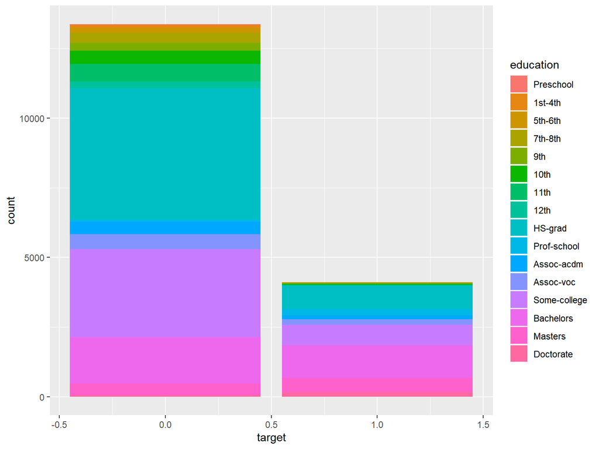

```r
# 학력은 높을 수록, 특히나 some college 이상부터는 y 변수에 영향을 많이 주는 것 같습니다
cat_data %>% ggplot(aes(x=target, fill = education)) + geom_bar()
```

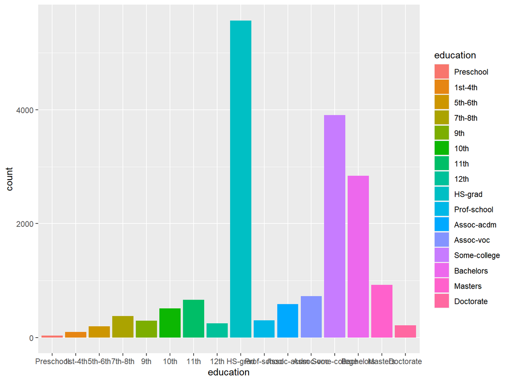

```r
cat_data %>% ggplot(aes(x=education, fill = education)) + geom_bar()
```

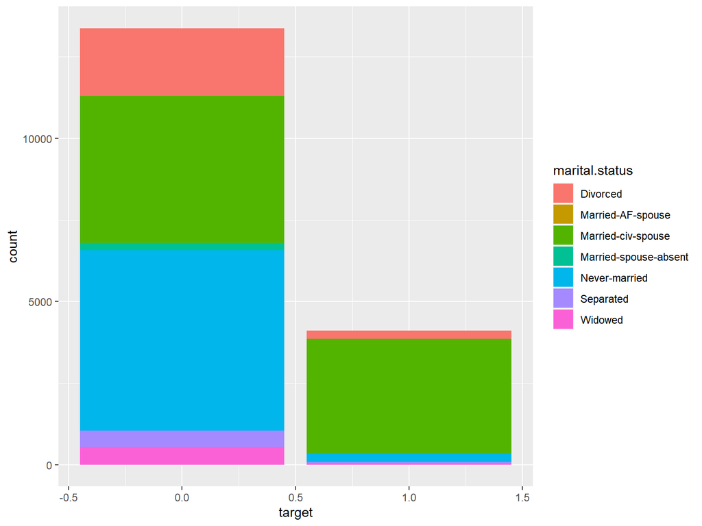

```r
# 결혼 상태는 Married-civ-spouse과 같은 class는 수익에 많은 영향을 주는 것 같으며
# Never-married는 오히려 수익을 낮추는 영향을 주는 것 같습니다
cat_data %>% ggplot(aes(x=target, fill = marital.status)) + geom_bar()
```

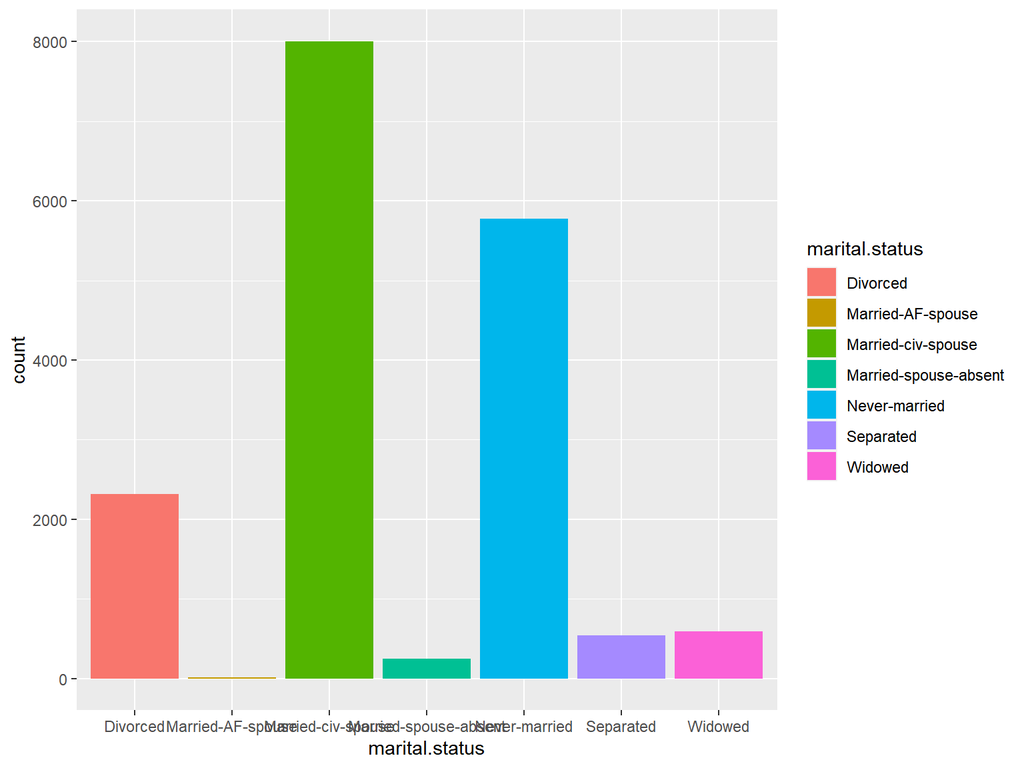

```r
cat_data %>% ggplot(aes(x=marital.status, fill = marital.status)) + geom_bar()
```

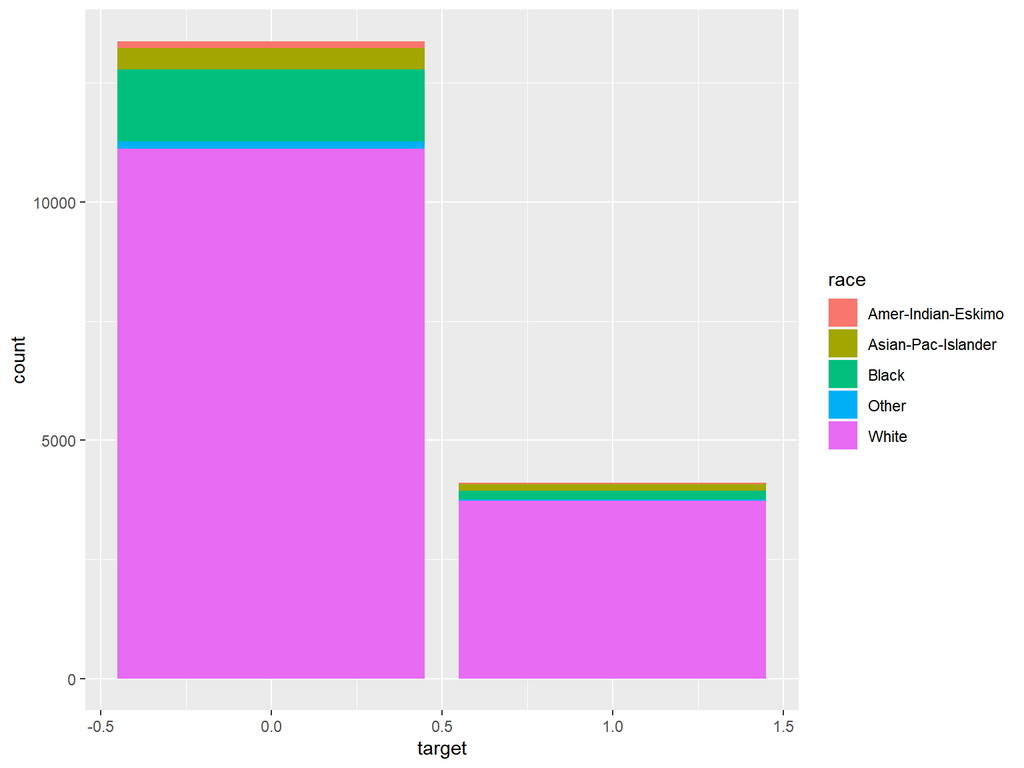

```r
# 인종은 white가 압도적으로 분포가 많습니다
# 그 다음으로 Black이 많은데 y 변수와의 관계성에서는 대체로 수익을 낮게 벌고 있습니다
cat_data %>% ggplot(aes(x=target, fill = race)) + geom_bar()
```

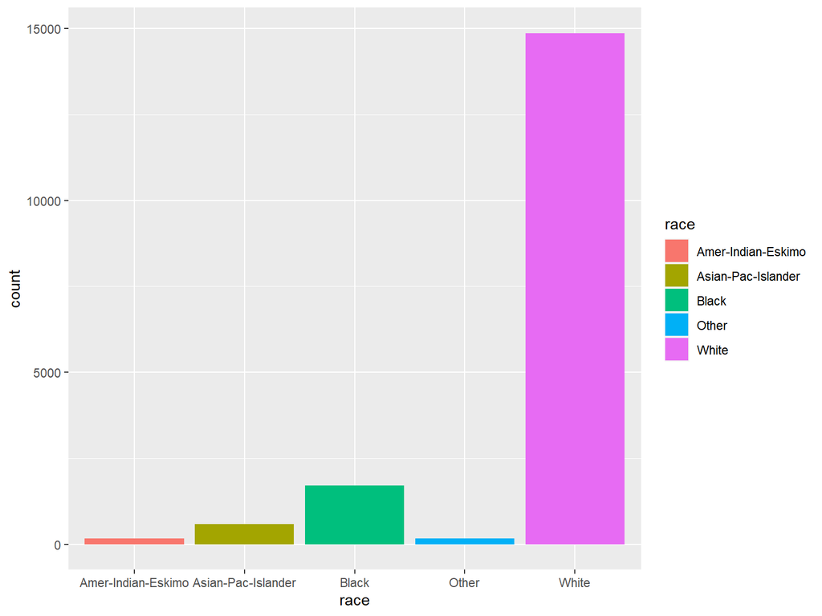

```r
cat_data %>% ggplot(aes(x=race, fill = race)) + geom_bar()
```

범주형 변수들에 대해 각각이 가지는 class별 분포와 y 변수와의 관계를 확인하기 위해 Bar plot을 확인하였다.  
Graph를 모두 확인하였지만 보고서의 분량을 감안하여 특정 3개의 변수에 대해서 짧은 추론을 주석과 함께 작성하였다.

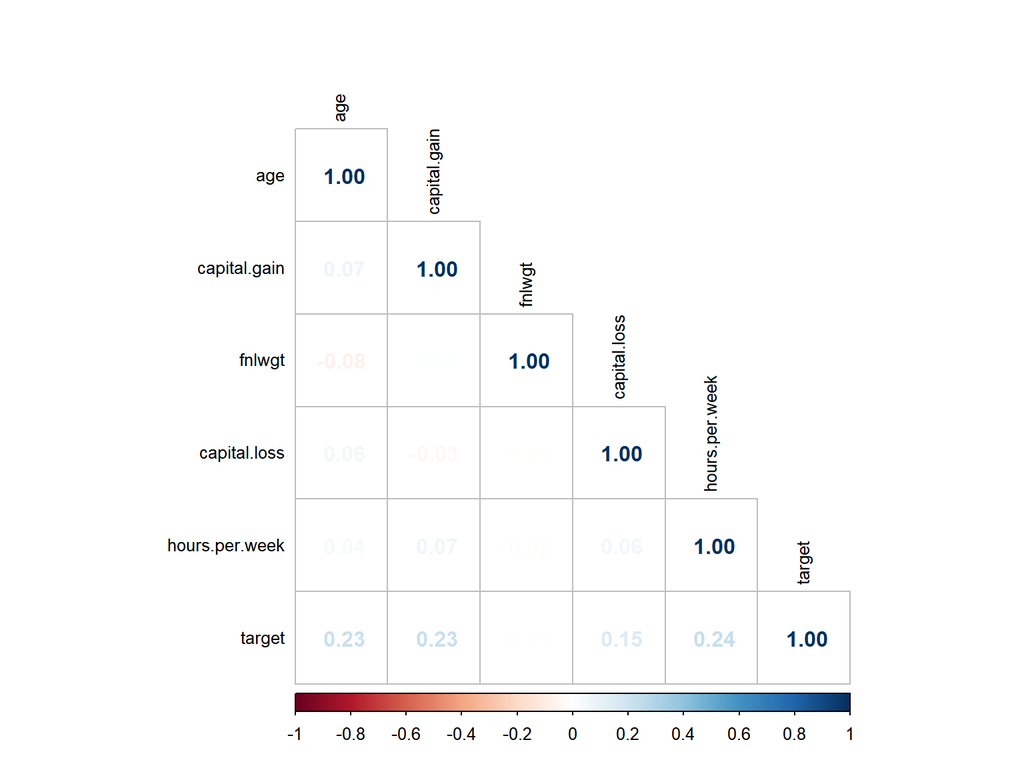

```r
# Numerical Variable EDA
# Correlation matrix
num_corr <- cor(num_data, method="pearson")
corrplot(num_corr,method="number",type="lower",order="hclust",tl.cex=.8, tl.col='black')
```

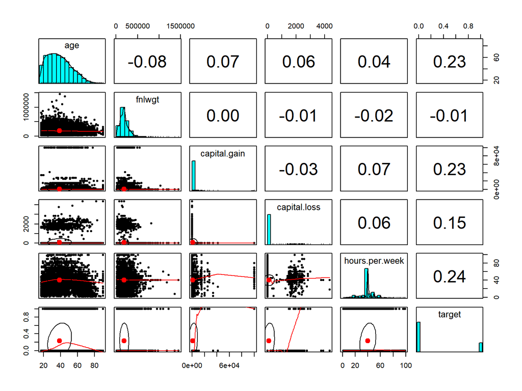

```r
# Histogram, Correlation, Scatter plot
pairs.panels(num_data)
```

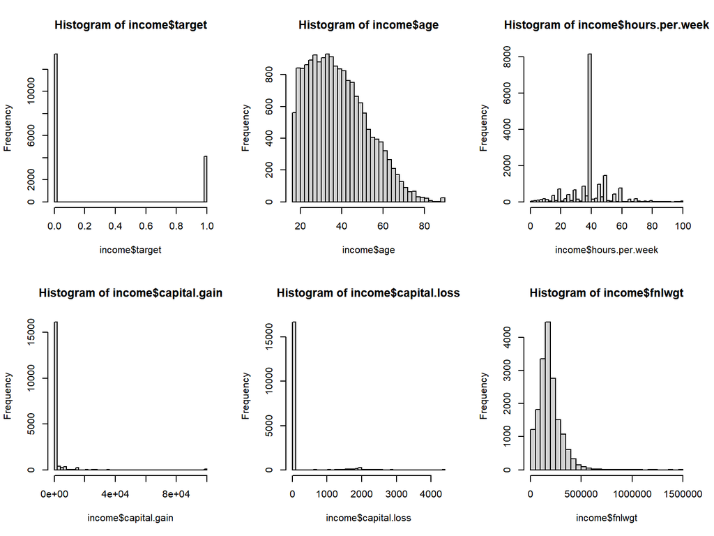

```r
# more detailed Histogram
par(mfrow=c(2,3))
hist(income$target, breaks=50)
hist(income$age, breaks=50)
hist(income$hours.per.week, breaks=50)
hist(income$capital.gain, breaks=50)
hist(income$capital.loss, breaks=50)
hist(income$fnlwgt, breaks=50)
```

```r
describe(num_data)
```

```
## Description of num_data
```

```
##
##  Numeric
##                     mean median          var        sd valid.n
## age                38.72     37 1.982400e+02     14.08   17480
## fnlwgt         189760.96 178134 1.102352e+10 104992.94   17480
## capital.gain     1076.64      0 5.534614e+07   7439.50   17480
## capital.loss       83.87      0 1.568420e+05    396.03   17480
## hours.per.week     40.00     40 1.605600e+02     12.67   17480
## target              0.23      0 1.800000e-01      0.42   17480
```

차례대로 correlation matrix, scatter plot, histogram(bar plot)을 사용하여 연속형 변수의 분포와 상관계수를 확인하였고 추가적으로 연속형 변수이기에 전반적인 통계량을 같이 확인하였다.  
이때 각 변수들간의 0.3 이상의 상관관계도 보이지 않으므로 해당 변수들간의 다중공선성 문제는 보이지 않을 것으로 예상된다. 이는 각각의 변수가 독립적인 특성이 크고 그렇다면 최종 모델을 구축할 때 feature selection의 역할이 크지 않을 것으로 예상된다. target 변수의 분포를 보면 5만 달러 이하의 사람들(label 0)이 더 많음을 알 수 있다. capital.gain, capital.loss, fnlwgt의 분포를 보았을 때 skewness가 크게 느껴지며 편차가 클 것으로 예상되는데 실제 통계량도 그러하였고, 가격/돈과 관련된 변수이기 때문에 사람들마다 큰 편차를 보이는 것으로 추정된다.  
각 5개의 변수에 대해서 나이, 돈, 가중치의 스케일을 가지므로 적절한 스케일링을 적용해보고 성능에 차이를 비교해보아야 할 것이다.

# 3 Preprocessing Data

인구 데이터(income)의 전체적인 전처리 과정 요약은 다음과 같이 정리할 수 있다.  
구체적인 전처리 과정은 코드와 주석을 통해 확인할 수 있다.

**17,480 rows X 16 cols** **15,081 rows X 30 cols**

```r
# original data : income
# preprocessed data : input_data - 따로 저장
# drop unnecessary variable - id, education.num
cat_data <- subset(cat_data, select = -target)
input_data <- cbind(cat_data, num_data)

# remove missing values -> 15,081 rows x 14 cols
input_data <- na.omit(input_data)
str(input_data)
```

```
## 'data.frame':    15081 obs. of  14 variables:
##  $ workclass     : Factor w/ 8 levels "Federal-gov",..: 4 4 4 4 4 4 7 4 2 4 ...
##  $ education     : Factor w/ 16 levels "Preschool","1st-4th",..: 11 13 13 14 9 14 10 9 6 7 ...
##  $ marital.status: Factor w/ 7 levels "Divorced","Married-AF-spouse",..: 3 3 3 5 1 3 3 6 5 5 ...
##  $ occupation    : Factor w/ 14 levels "Adm-clerical",..: 3 4 3 1 1 10 10 7 8 12 ...
##  $ relationship  : Factor w/ 6 levels "Husband","Not-in-family",..: 1 1 1 4 2 1 1 5 4 2 ...
##  $ race          : Factor w/ 5 levels "Amer-Indian-Eskimo",..: 5 5 5 5 5 5 5 3 5 5 ...
##  $ sex           : Factor w/ 2 levels "Female","Male": 2 2 2 1 1 2 2 1 1 2 ...
##  $ native.country: Factor w/ 41 levels "Cambodia","Canada",..: 39 39 39 39 39 39 39 39 39 39 ...
##  $ age           : int  32 33 46 23 55 33 40 45 17 35 ...
##  $ fnlwgt        : int  309513 205469 149949 193090 60193 41610 40024 114797 39815 107991 ...
##  $ capital.gain  : int  0 0 0 0 0 0 0 0 0 0 ...
##  $ capital.loss  : int  0 0 0 0 0 0 0 0 0 0 ...
##  $ hours.per.week: int  40 40 40 30 40 40 38 40 25 45 ...
##  $ target        : int  0 1 0 0 0 0 1 0 0 0 ...
##  - attr(*, "na.action")= 'omit' Named int [1:2399] 15082 15083 15084 15085 15086 15087 15088 15089 15090 15091 ...
##   ..- attr(*, "names")= chr [1:2399] "15082" "15083" "15084" "15085" ...
```

```r
# Ordinal Encoding
edu_ol <- factor(c(input_data$education), levels = c("Preschool", "1st-4th", "5th-6th", "7th-8th", "9th", "10th", "11th", "12th",
  "HS-grad", "Prof-school", "Assoc-acdm", "Assoc-voc", "Some-college", "Bachelors", "Masters", "Doctorate"))
input_data$education <- unclass(edu_ol)

# Binary Encoding -> XXX

# Factor type -> auto create Dummy variable
```

범주형 변수는 학습 모델에 들어가기 전 숫자형 변수로 encoding 해주어야 한다. 특히 순서성이 없는 Nominal 변수에 대해서는 적절한 encoding 방식이 필요하다.  
그리하여 Ordinary 변수인 education 변수에 대해 Ordinal Encoding을 적용하였다.  
Nominal 변수에 대해서는 Binary Encoding 방식을 선택했었다. 이유는 Binary Encoding 방식은 One-hot encoding 방식보다 더 적은 dummy 변수를 만들어내면서 순차성 정보를 내재하지 않으면서 변환할 수 있기 때문이였으나 몇 번의 테스트 끝에 binary encoding 보다 factor type의 변수를 linear model이 자동으로 dummy variable로 변환해줄 때 모든 모델들에 대해서 약 0.04% 성능향상을 보였다. 어떤 Encdoing 방식이든 최고의 방식은 존재하지 않기에 자동으로 dummy variable을 생성하는 방식을 채택하게 되었다.

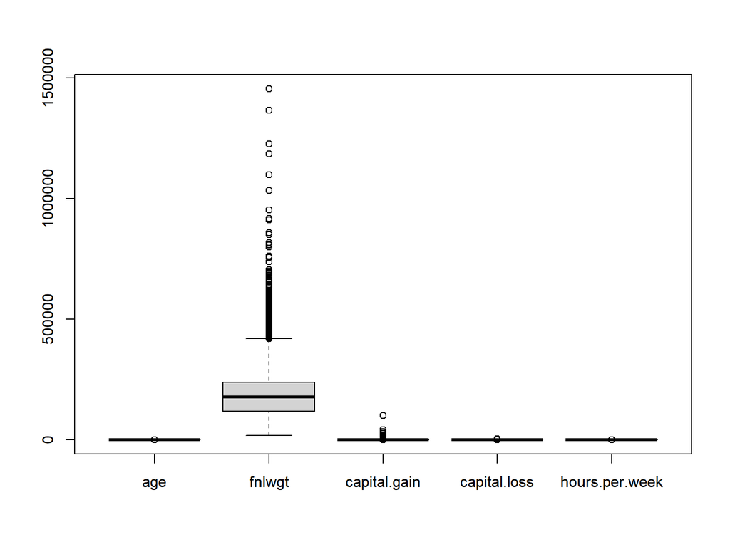

```r
# y variable을 제외하고 numerical 변수에 대해서 정규화 전처리를 진행
scale_data <- subset(input_data, select = c(age, fnlwgt, capital.gain, capital.loss, hours.per.week))
boxplot(scale_data)
```

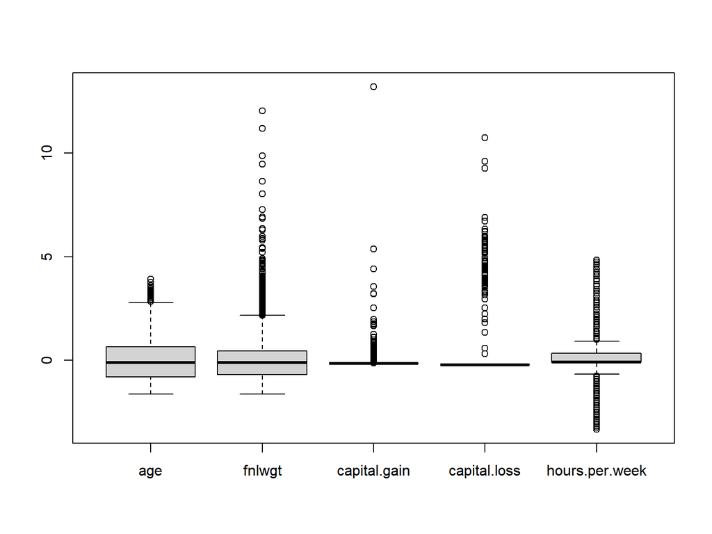

```r
# Standardization 표준화
scale <- caret::preProcess(scale_data, method = c("center", "scale"))
scale_data <- predict(scale, scale_data)
boxplot(scale_data)
```

```r
input_data <- input_data %>% select(-age, -fnlwgt, -capital.gain, -capital.loss, -hours.per.week)
input_data <- cbind(input_data, scale_data)
input_data$target <- as.numeric(input_data$target)
rm(scale_data, scale)
```

Standardization 표준화는 중심극한 정리와 표준정규분포를 이용하여 각 변수들의 분포를 정규분포에 비슷하게 만들어준다. 해당 전처리 과정은 특히나 선형회귀, 로지스틱회귀에서 유용한 기법이다. 전처리 전, 후 과정을 Box plot을 통해 확인하였고 분포의 변화를 확인할 수 있다.

# 4 Data Split

모델 구축과 학습에 앞서 전체 데이터를 8:2의 비율로 학습/테스트 데이터로 분합한다.

**15,081 rows X 30 cols**

- Train data : 12,065 rows
  - train_data
- Test data : 3,016 rows
  - test_data

```r
set.seed(2020)
test_id <- sample(1:nrow(input_data), round(nrow(input_data)*0.20))
train_data <- input_data[-test_id, ]
test_data <- input_data[test_id, ]

print("Training: ", str(nrow(train_data))) # train data 개수
```

```
##  int 12065
## [1] "Training: "
```

```r
print("Test: ", str(nrow(test_data)))      # test data 개수
```

```
##  int 3016
## [1] "Test: "
```

# 5 Modeling

분할한 데이터를 가지고 모든 변수들을 사용하는 모델과 Heuristic method의 feature selection을 적용한 모델들을 최종적으로 비교할 예정이다.  
모든 모델들은 동일한 전처리 과정을 거쳤고 같은 데이터를 이용하여 학습 및 테스트 하였으며 최종적으로 4가지의 모델이 구축되었다. 각 모델의 평가지표는 다음과 같이 요약할 수 있다. 자세항 사항은 코드와 함께 밑에서 확인할 수 있다.

**Forward Selection Logistic Linear Regression**

- forward selection
- target ~ relationship, occupation, capital.gain, education, hours.per.week, capital.loss, age, sex, marital, workclass, race, fnlwgt
- ACC 0.842
- Recall 0.72
- Precision 0.61
- F1 score 0.66

**Backward Elimination Logistic Linear Regression**

- backward elimination
- target ~ workclass, education, marital, occupation, relationship, race, sex, age, fnlwgt, capital.gain, capital.loss, hours.per.week
- ACC 0.842
- Recall 0.72
- Precision 0.61
- F1 score 0.66

**Stepwise Selection Logistic Linear Regression**

- stepwise selection
- target ~ workclass, education, marital, occupation, relationship, race, sex, age, fnlwgt, capital.gain, capital.loss, hourse.per.week
- ACC 0.842
- Recall 0.72
- Precision 0.61
- F1 score 0.66

## 5.1 Model 1 : No feature selection

```r
# Training
model_multi <- glm(target ~ ., data =train_data)
summary(model_multi)
```

```
##
## Call:
## glm(formula = target ~ ., data = train_data)
##
## Deviance Residuals:
##      Min        1Q    Median        3Q       Max
## -0.89648  -0.25153  -0.04402   0.18751   1.22853
##
## Coefficients:
##                                            Estimate Std. Error t value Pr(>|t|)
## (Intercept)                               0.1503380  0.1397422   1.076 0.282028
## workclassLocal-gov                       -0.0924750  0.0224589  -4.118 3.86e-05
## workclassPrivate                         -0.0817680  0.0190544  -4.291 1.79e-05
## workclassSelf-emp-inc                    -0.0194803  0.0251190  -0.776 0.438047
## workclassSelf-emp-not-inc                -0.1328909  0.0221389  -6.003 2.00e-09
## workclassState-gov                       -0.0982729  0.0238573  -4.119 3.83e-05
## workclassWithout-pay                     -0.2908422  0.1435020  -2.027 0.042710
## education                                 0.0216008  0.0012822  16.847  < 2e-16
## marital.statusMarried-AF-spouse           0.2644285  0.1060572   2.493 0.012671
## marital.statusMarried-civ-spouse          0.1636839  0.0388769   4.210 2.57e-05
## marital.statusMarried-spouse-absent       0.0378107  0.0288802   1.309 0.190482
## marital.statusNever-married               0.0050822  0.0117821   0.431 0.666222
## marital.statusSeparated                   0.0115328  0.0203262   0.567 0.570463
## marital.statusWidowed                     0.0067081  0.0215869   0.311 0.755997
## occupationArmed-Forces                   -0.2525811  0.3486150  -0.725 0.468756
## occupationCraft-repair                   -0.0347236  0.0137574  -2.524 0.011616
## occupationExec-managerial                 0.1401551  0.0131567  10.653  < 2e-16
## occupationFarming-fishing                -0.1123567  0.0211916  -5.302 1.17e-07
## occupationHandlers-cleaners              -0.0633835  0.0185040  -3.425 0.000616
## occupationMachine-op-inspct              -0.0545735  0.0159958  -3.412 0.000648
## occupationOther-service                  -0.0179720  0.0138269  -1.300 0.193698
## occupationPriv-house-serv                 0.0364020  0.0460185   0.791 0.428942
## occupationProf-specialty                  0.1263181  0.0132769   9.514  < 2e-16
## occupationProtective-serv                 0.0420500  0.0243085   1.730 0.083682
## occupationSales                           0.0514779  0.0134909   3.816 0.000136
## occupationTech-support                    0.0574748  0.0205248   2.800 0.005114
## occupationTransport-moving               -0.0614010  0.0176830  -3.472 0.000518
## relationshipNot-in-family                -0.1112257  0.0385914  -2.882 0.003957
## relationshipOther-relative               -0.0957887  0.0380773  -2.516 0.011895
## relationshipOwn-child                    -0.0947622  0.0385582  -2.458 0.013999
```

[output cut: 130 more lines]

```
## age                                      ***
## fnlwgt                                   *
## capital.gain                             ***
## capital.loss                             ***
## hours.per.week                           ***
## ---
## Signif. codes:  0 '***' 0.001 '**' 0.01 '*' 0.05 '.' 0.1 ' ' 1
##
## (Dispersion parameter for gaussian family taken to be 0.1209596)
##
##     Null deviance: 2254.0  on 12064  degrees of freedom
## Residual deviance: 1449.5  on 11983  degrees of freedom
## AIC: 8837.8
##
## Number of Fisher Scoring iterations: 2
```

```r
perf_eval <- function(cm){
  # true positive rate
  TPR = Recall = cm[2,2]/sum(cm[2,])
  # precision
  Precision = cm[2,2]/sum(cm[,2])
  # true negative rate
  TNR = cm[1,1]/sum(cm[1,])
  # accuracy
  ACC = sum(diag(cm)) / sum(cm)
  # balance corrected accuracy (geometric mean)
  BCR = sqrt(TPR*TNR)
  # f1 measure
  F1 = 2 * Recall * Precision / (Recall + Precision)

  re <- data.frame(TPR = TPR,
                   Precision = Precision,
                   TNR = TNR,
                   ACC = ACC,
                   BCR = BCR,
                   F1 = F1)
  return(re)
}

# prediction
pred_prob <- predict(model_multi, test_data, type="response")
pred_class <- rep(0, nrow(test_data))
pred_class[pred_prob > 0.3] <- 1
cm <- table(pred=pred_class, actual=test_data$target)
# ACC, Recall, Precision, F1 score
perf_eval(cm)
```

```
##         TPR Precision       TNR       ACC       BCR        F1
## 1 0.5465587 0.8732212 0.9449747 0.7818302 0.7186683 0.6723108
```

## 5.2 Model 2 : Forward Selection

변수를 하나씩 추가해가면서 중요 변수를 선택하는 방법으로 학습 모델을 구축하고 평가해보았다.

```r
# Training
model_fwd <- step(glm(target ~ 1, train_data,
                      family = binomial()),
                  direction = "forward", trace = 0,
                  scope = formula(model_multi))
summary(model_fwd)
```

```
##
## Call:
## glm(formula = target ~ relationship + occupation + capital.gain +
##     education + hours.per.week + capital.loss + age + sex + marital.status +
##     workclass + race + fnlwgt, family = binomial(), data = train_data)
##
## Deviance Residuals:
##     Min       1Q   Median       3Q      Max
## -3.7062  -0.5328  -0.2041  -0.0002   3.2594
##
## Coefficients:
##                                       Estimate Std. Error z value Pr(>|z|)
## (Intercept)                           -5.81927    0.57683 -10.088  < 2e-16 ***
## relationshipNot-in-family              0.87456    0.40865   2.140 0.032343 *
## relationshipOther-relative            -0.47691    0.39641  -1.203 0.228940
## relationshipOwn-child                 -0.39508    0.40498  -0.976 0.329276
## relationshipUnmarried                  0.67251    0.43415   1.549 0.121372
## relationshipWife                       1.22708    0.16096   7.624 2.47e-14 ***
## occupationArmed-Forces               -14.01831 1455.39755  -0.010 0.992315
## occupationCraft-repair                -0.07023    0.12405  -0.566 0.571289
## occupationExec-managerial              0.78264    0.11815   6.624 3.49e-11 ***
## occupationFarming-fishing             -0.96829    0.20995  -4.612 3.99e-06 ***
## occupationHandlers-cleaners           -0.85194    0.22685  -3.756 0.000173 ***
## occupationMachine-op-inspct           -0.40526    0.15903  -2.548 0.010826 *
## occupationOther-service               -0.87877    0.18487  -4.753 2.00e-06 ***
## occupationPriv-house-serv            -12.15924  157.17532  -0.077 0.938336
## occupationProf-specialty               0.74354    0.12018   6.187 6.13e-10 ***
## occupationProtective-serv              0.33249    0.19342   1.719 0.085610 .
## occupationSales                        0.28529    0.12785   2.231 0.025654 *
## occupationTech-support                 0.46885    0.17197   2.726 0.006404 **
## occupationTransport-moving            -0.27535    0.15700  -1.754 0.079459 .
## capital.gain                           2.17859    0.12089  18.021  < 2e-16 ***
## education                              0.19500    0.01189  16.398  < 2e-16 ***
## hours.per.week                         0.41946    0.03161  13.270  < 2e-16 ***
## capital.loss                           0.26712    0.02386  11.194  < 2e-16 ***
## age                                    0.35990    0.03443  10.452  < 2e-16 ***
## sexMale                                0.88266    0.12406   7.115 1.12e-12 ***
## marital.statusMarried-AF-spouse        3.40667    0.80221   4.247 2.17e-05 ***
## marital.statusMarried-civ-spouse       2.49205    0.41553   5.997 2.01e-09 ***
## marital.statusMarried-spouse-absent   -0.10779    0.34987  -0.308 0.758009
```

[output cut: 9 more lines]

```
## raceAsian-Pac-Islander                 0.10420    0.36946   0.282 0.777925
## raceBlack                              0.16888    0.34987   0.483 0.629310
## raceOther                             -0.51174    0.55668  -0.919 0.357954
## raceWhite                              0.37229    0.33058   1.126 0.260091
## fnlwgt                                 0.04975    0.02810   1.770 0.076686 .
## ---
## Signif. codes:  0 '***' 0.001 '**' 0.01 '*' 0.05 '.' 0.1 ' ' 1
##
## (Dispersion parameter for binomial family taken to be 1)
##
##     Null deviance: 13533.3  on 12064  degrees of freedom
## Residual deviance:  8039.3  on 12023  degrees of freedom
## AIC: 8123.3
##
## Number of Fisher Scoring iterations: 14
```

```r
# Prediction
pred_prob <- predict(model_fwd, test_data, type="response")
pred_class <- rep(0, nrow(test_data))
pred_class[pred_prob > 0.5] <- 1
cm <- table(pred=pred_class, actual=test_data$target)
# ACC, Recall, Precision, F1 score
perf_eval(cm)
```

```
##         TPR Precision       TNR       ACC      BCR        F1
## 1 0.7295209  0.610608 0.8729422 0.8421751 0.798016 0.6647887
```

## 5.3 Model 3 : Backward Elimination

유의미하지 않은 변수를 하나씩 제거해가면서 중요 변수를 선택하는 방법으로 학습 모델을 구축하고 평가해보았다.

```r
# Training
model_bwd <- step(glm(target ~ ., train_data,
                      family = binomial()),
                  direction = "backward", trace = 0,
                  scope = list(lower=target ~ 1, upper = formula(model_multi)))
summary(model_bwd)
```

```
##
## Call:
## glm(formula = target ~ workclass + education + marital.status +
##     occupation + relationship + race + sex + age + fnlwgt + capital.gain +
##     capital.loss + hours.per.week, family = binomial(), data = train_data)
##
## Deviance Residuals:
##     Min       1Q   Median       3Q      Max
## -3.7062  -0.5328  -0.2041  -0.0002   3.2594
##
## Coefficients:
##                                       Estimate Std. Error z value Pr(>|z|)
## (Intercept)                           -5.81927    0.57683 -10.088  < 2e-16 ***
## workclassLocal-gov                    -0.58642    0.17703  -3.312 0.000925 ***
## workclassPrivate                      -0.55416    0.14816  -3.740 0.000184 ***
## workclassSelf-emp-inc                 -0.44465    0.19076  -2.331 0.019758 *
## workclassSelf-emp-not-inc             -0.91551    0.17312  -5.288 1.24e-07 ***
## workclassState-gov                    -0.67533    0.19223  -3.513 0.000443 ***
## workclassWithout-pay                 -14.43872  509.29415  -0.028 0.977383
## education                              0.19500    0.01189  16.398  < 2e-16 ***
## marital.statusMarried-AF-spouse        3.40667    0.80221   4.247 2.17e-05 ***
## marital.statusMarried-civ-spouse       2.49205    0.41553   5.997 2.01e-09 ***
## marital.statusMarried-spouse-absent   -0.10779    0.34987  -0.308 0.758009
## marital.statusNever-married           -0.27063    0.13581  -1.993 0.046288 *
## marital.statusSeparated               -0.09746    0.26270  -0.371 0.710632
## marital.statusWidowed                  0.03549    0.25647   0.138 0.889947
## occupationArmed-Forces               -14.01831 1455.39755  -0.010 0.992315
## occupationCraft-repair                -0.07023    0.12405  -0.566 0.571289
## occupationExec-managerial              0.78264    0.11815   6.624 3.49e-11 ***
## occupationFarming-fishing             -0.96829    0.20995  -4.612 3.99e-06 ***
## occupationHandlers-cleaners           -0.85194    0.22685  -3.756 0.000173 ***
## occupationMachine-op-inspct           -0.40526    0.15903  -2.548 0.010826 *
## occupationOther-service               -0.87877    0.18487  -4.753 2.00e-06 ***
## occupationPriv-house-serv            -12.15924  157.17532  -0.077 0.938336
## occupationProf-specialty               0.74354    0.12018   6.187 6.13e-10 ***
## occupationProtective-serv              0.33249    0.19342   1.719 0.085610 .
## occupationSales                        0.28529    0.12785   2.231 0.025654 *
## occupationTech-support                 0.46885    0.17197   2.726 0.006404 **
## occupationTransport-moving            -0.27535    0.15700  -1.754 0.079459 .
## relationshipNot-in-family              0.87456    0.40865   2.140 0.032343 *
```

[output cut: 9 more lines]

```
## age                                    0.35990    0.03443  10.452  < 2e-16 ***
## fnlwgt                                 0.04975    0.02810   1.770 0.076686 .
## capital.gain                           2.17859    0.12089  18.021  < 2e-16 ***
## capital.loss                           0.26712    0.02386  11.194  < 2e-16 ***
## hours.per.week                         0.41946    0.03161  13.270  < 2e-16 ***
## ---
## Signif. codes:  0 '***' 0.001 '**' 0.01 '*' 0.05 '.' 0.1 ' ' 1
##
## (Dispersion parameter for binomial family taken to be 1)
##
##     Null deviance: 13533.3  on 12064  degrees of freedom
## Residual deviance:  8039.3  on 12023  degrees of freedom
## AIC: 8123.3
##
## Number of Fisher Scoring iterations: 14
```

```r
# Prediction
pred_prob <- predict(model_bwd, test_data, type="response")
pred_class <- rep(0, nrow(test_data))
pred_class[pred_prob > 0.5] <- 1
cm <- table(pred=pred_class, actual=test_data$target)
# ACC, Recall, Precision, F1 score
perf_eval(cm)
```

```
##         TPR Precision       TNR       ACC      BCR        F1
## 1 0.7295209  0.610608 0.8729422 0.8421751 0.798016 0.6647887
```

## 5.4 Model 4 : Stepwise Selection

앞선 forward selection 과 backward elimination 방법을 번갈아가면서 수행하는 방법으로 학습 모델을 구축하고 평가해보았다.

```r
# Training
model_step <- step(glm(target ~ ., train_data,
                       family = binomial()), direction = "both", trace = 0,
                  scope = list(lower=target ~ 1, upper = formula(model_multi)))
summary(model_step)
```

```
##
## Call:
## glm(formula = target ~ workclass + education + marital.status +
##     occupation + relationship + race + sex + age + fnlwgt + capital.gain +
##     capital.loss + hours.per.week, family = binomial(), data = train_data)
##
## Deviance Residuals:
##     Min       1Q   Median       3Q      Max
## -3.7062  -0.5328  -0.2041  -0.0002   3.2594
##
## Coefficients:
##                                       Estimate Std. Error z value Pr(>|z|)
## (Intercept)                           -5.81927    0.57683 -10.088  < 2e-16 ***
## workclassLocal-gov                    -0.58642    0.17703  -3.312 0.000925 ***
## workclassPrivate                      -0.55416    0.14816  -3.740 0.000184 ***
## workclassSelf-emp-inc                 -0.44465    0.19076  -2.331 0.019758 *
## workclassSelf-emp-not-inc             -0.91551    0.17312  -5.288 1.24e-07 ***
## workclassState-gov                    -0.67533    0.19223  -3.513 0.000443 ***
## workclassWithout-pay                 -14.43872  509.29415  -0.028 0.977383
## education                              0.19500    0.01189  16.398  < 2e-16 ***
## marital.statusMarried-AF-spouse        3.40667    0.80221   4.247 2.17e-05 ***
## marital.statusMarried-civ-spouse       2.49205    0.41553   5.997 2.01e-09 ***
## marital.statusMarried-spouse-absent   -0.10779    0.34987  -0.308 0.758009
## marital.statusNever-married           -0.27063    0.13581  -1.993 0.046288 *
## marital.statusSeparated               -0.09746    0.26270  -0.371 0.710632
## marital.statusWidowed                  0.03549    0.25647   0.138 0.889947
## occupationArmed-Forces               -14.01831 1455.39755  -0.010 0.992315
## occupationCraft-repair                -0.07023    0.12405  -0.566 0.571289
## occupationExec-managerial              0.78264    0.11815   6.624 3.49e-11 ***
## occupationFarming-fishing             -0.96829    0.20995  -4.612 3.99e-06 ***
## occupationHandlers-cleaners           -0.85194    0.22685  -3.756 0.000173 ***
## occupationMachine-op-inspct           -0.40526    0.15903  -2.548 0.010826 *
## occupationOther-service               -0.87877    0.18487  -4.753 2.00e-06 ***
## occupationPriv-house-serv            -12.15924  157.17532  -0.077 0.938336
## occupationProf-specialty               0.74354    0.12018   6.187 6.13e-10 ***
## occupationProtective-serv              0.33249    0.19342   1.719 0.085610 .
## occupationSales                        0.28529    0.12785   2.231 0.025654 *
## occupationTech-support                 0.46885    0.17197   2.726 0.006404 **
## occupationTransport-moving            -0.27535    0.15700  -1.754 0.079459 .
## relationshipNot-in-family              0.87456    0.40865   2.140 0.032343 *
```

[output cut: 9 more lines]

```
## age                                    0.35990    0.03443  10.452  < 2e-16 ***
## fnlwgt                                 0.04975    0.02810   1.770 0.076686 .
## capital.gain                           2.17859    0.12089  18.021  < 2e-16 ***
## capital.loss                           0.26712    0.02386  11.194  < 2e-16 ***
## hours.per.week                         0.41946    0.03161  13.270  < 2e-16 ***
## ---
## Signif. codes:  0 '***' 0.001 '**' 0.01 '*' 0.05 '.' 0.1 ' ' 1
##
## (Dispersion parameter for binomial family taken to be 1)
##
##     Null deviance: 13533.3  on 12064  degrees of freedom
## Residual deviance:  8039.3  on 12023  degrees of freedom
## AIC: 8123.3
##
## Number of Fisher Scoring iterations: 14
```

```r
# Prediction
pred_prob <- predict(model_step, test_data, type="response")
pred_class <- rep(0, nrow(test_data))
pred_class[pred_prob > 0.5] <- 1
cm <- table(pred=pred_class, actual=test_data$target)
# ACC, Recall, Precision, F1 score
perf_eval(cm)
```

```
##         TPR Precision       TNR       ACC      BCR        F1
## 1 0.7295209  0.610608 0.8729422 0.8421751 0.798016 0.6647887
```

종속 변수 y에 유의미한 변수만을 남겨가는 과정으로 학습모델을 구축한 결과 역시나 최종적으로 native.country 변수가 탈락하였다. 이로써 모든 방법론들에서 **native.country 변수를 가장 유의미하지 못한 변수로 선정하였음을 알 수 있다.** 평가 지표 또한 앞선 방식들의 모델들과 동일하다.

# 6 Evaluation

## 6.1 ANOVA

다중 선형 회귀 모델간의 비교를 위해서 ANOVA 진행하여 분산의 차이가 있는지 가설 검정을 진행하였다. 여기서 평균을 비교하지 않고 분산을 비교한 이유는 평균이 아니라 얼마나 퍼져있는지 보는게 더 중요하기 때문이다.

```r
anova(model_multi, model_fwd, test="Chisq")
```

```
## Analysis of Deviance Table
##
## Model 1: target ~ workclass + education + marital.status + occupation +
##     relationship + race + sex + native.country + age + fnlwgt +
##     capital.gain + capital.loss + hours.per.week
## Model 2: target ~ relationship + occupation + capital.gain + education +
##     hours.per.week + capital.loss + age + sex + marital.status +
##     workclass + race + fnlwgt
##   Resid. Df Resid. Dev  Df Deviance  Pr(>Chi)
## 1     11983     1449.5
## 2     12023     8039.3 -40  -6589.9 < 2.2e-16 ***
## ---
## Signif. codes:  0 '***' 0.001 '**' 0.01 '*' 0.05 '.' 0.1 ' ' 1
```

```r
anova(model_multi, model_bwd, test="Chisq")
```

```
## Analysis of Deviance Table
##
## Model 1: target ~ workclass + education + marital.status + occupation +
##     relationship + race + sex + native.country + age + fnlwgt +
##     capital.gain + capital.loss + hours.per.week
## Model 2: target ~ workclass + education + marital.status + occupation +
##     relationship + race + sex + age + fnlwgt + capital.gain +
##     capital.loss + hours.per.week
##   Resid. Df Resid. Dev  Df Deviance  Pr(>Chi)
## 1     11983     1449.5
## 2     12023     8039.3 -40  -6589.9 < 2.2e-16 ***
## ---
## Signif. codes:  0 '***' 0.001 '**' 0.01 '*' 0.05 '.' 0.1 ' ' 1
```

```r
anova(model_multi, model_step, test="Chisq")
```

```
## Analysis of Deviance Table
##
## Model 1: target ~ workclass + education + marital.status + occupation +
##     relationship + race + sex + native.country + age + fnlwgt +
##     capital.gain + capital.loss + hours.per.week
## Model 2: target ~ workclass + education + marital.status + occupation +
##     relationship + race + sex + age + fnlwgt + capital.gain +
##     capital.loss + hours.per.week
##   Resid. Df Resid. Dev  Df Deviance  Pr(>Chi)
## 1     11983     1449.5
## 2     12023     8039.3 -40  -6589.9 < 2.2e-16 ***
## ---
## Signif. codes:  0 '***' 0.001 '**' 0.01 '*' 0.05 '.' 0.1 ' ' 1
```